# A R Markdown file with images and tables

# 1 Requirements for this lab

In this lab, you are required to use the skills learned from Module 7 to create a R Markdown which includes images and tables. And, you are required to index and refer to the images and tables in this R Markdown file.

#### Please download the data Download data here into a folder you want to have as your working directory.

#### Please create a R Markdown file, set the output format as pdf_document or html_document2. Finally knit the R Markdown file into the PDF or HTML file.

#### Please use the data provided to conduct a **A R Markdown file with images and tables** based on the step mentioned below.

- > Steps:
  > 1. Install and load required packages.
  > 2. Load and inspect the dataset.
  > 3. Create a table to show the first 10 rows of the original data
  > 4. Create a table to show the statistical values of mean values, max valuess and min values by group_by (Year)
  > 5. Plot a histogram for the variable “CrimeRate”
  > 6. Plot a scatter plot for the variable “Year” and ” Crimerate”
  > 7. In the Markdown section(text documents), please refer to all the tables and plots you create. That means you need to label them inside the code chunks.
  > 8. In this lab, please set “pdf_document” for output file format. Please use `Table \ref{tab:Your chunk name}` or `Figure \ref{fig:Your chunk name}` to refer to the tables or images. This is what we introduced in the short videos. For example:

  ```
      >> In Figure \ref{fig:plot1}, we can see another plotting example.
      >>`{r plot1,echo=FALSE,fig.width=7,fig.height=6,fig.cap="\\label{fig:plot1}A histogram of Crime Rate over USA"}`
      >>* In Table \ref{tab:table2}, we see the table.
      >>`{r table2}`\
      >>`kable(df_new,caption= "\\label{tab:table2}A Statistics table")`\
  ```

  > 9. If Step 8 doesn’t work, please set “bookdown::html_document2” for output file format. Please install the pacakge “bookdown” first. Please use `Table \@ref(tab:your chunk name)` or `Figure \@ref(fig:your chunk name)` to refer to the tables or images. For example:

  ```
      >> In Figure \@ref(fig:plot1), we can see the grouped histogram for each year.\
      >>`{r plot1,echo=FALSE,fig.width=7,fig.height=6,fig.cap="A histogram of Crime Rate over USA"}`\
      >>In Table \@ref(tab:table2), we see the basic statistical values of crime rates over USA for each year.\
      >>`{r table2}`\
      >>`kable(df_new,caption= "A Statistics table")`\
  ```

#### Please name your file as *Yourname_7.3_RMarkdown_Images and Tables.RMD*.

#### Please knit your R Markdown file into a PDF or HTML file and submit the PDF or HTML file.

## 1.1 Create Tables

### Original data

In Table 1.1, we see the first 10 rows of the `Crmate Rate` data”.

Table 1.1: The first 10 rows of the `Crmate Rate` data

| State | Year | CrimeRate |
| --- | --- | --- |
| Alabama | 2007 | 448.0 |
| Alabama | 2008 | 452.8 |
| Alabama | 2009 | 450.1 |
| Alabama | 2010 | 377.8 |
| Alabama | 2011 | 419.8 |
| Alabama | 2012 | 449.9 |
| Alabama | 2013 | 431.0 |
| Alabama | 2014 | 427.4 |
| Alabama | 2015 | 473.0 |
| Alabama | 2016 | 532.3 |

### Statistics data

In Table 1.2, we see the basic statistical values of crime rates over USA for each year.

Table 1.2: A Statistics table

| Year | mean_rate | max_rate | min_rate |
| --- | --- | --- | --- |
| 2007 | 407.460 | 788.3 | 118.0 |
| 2008 | 399.982 | 729.7 | 117.5 |
| 2009 | 387.688 | 705.2 | 119.9 |
| 2010 | 365.590 | 660.6 | 122.0 |
| 2011 | 354.274 | 610.1 | 123.3 |
| 2012 | 353.826 | 643.6 | 122.7 |
| 2013 | 351.832 | 638.7 | 123.6 |
| 2014 | 346.806 | 635.8 | 99.3 |
| 2015 | 363.224 | 730.8 | 119.3 |
| 2016 | 378.038 | 804.2 | 123.8 |
| 2017 | 378.054 | 856.7 | 120.6 |
| 2018 | 365.618 | 885.0 | 112.1 |

## 1.2 Create plots

### A histogram plot

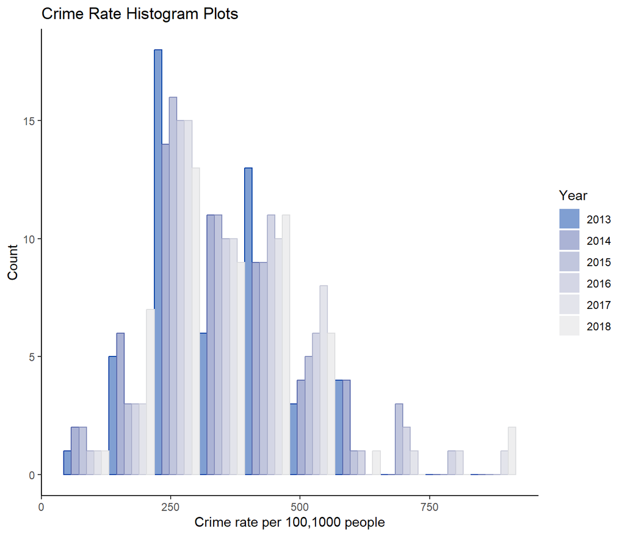

Figure 1.1: A histogram of Crime Rate over USA

### A scatter plot

In Figure 1.2, we can see the average crime rate changes along with years.

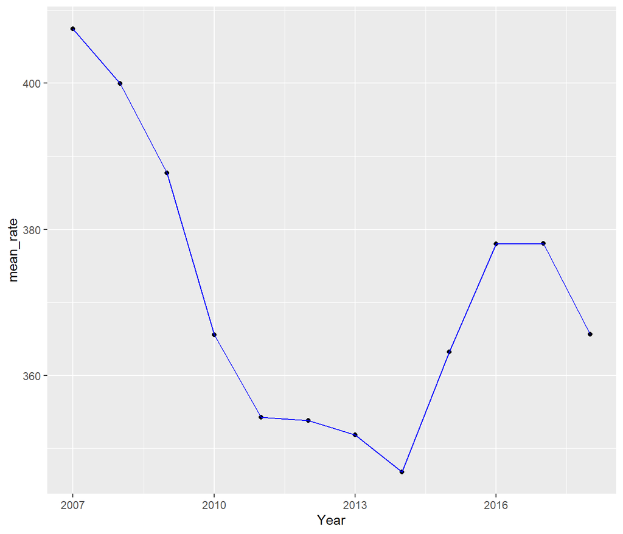

Figure 1.2: A scatter plot between Crime Rate with Year